# Exploring the BRFSS data

## Setup

### Load packages

```r
library(ggplot2)
library(dplyr)
```

### Load data

```r
load("brfss2013.RData")
```

## Part 1: Data

The BRFSS data set represents the data collected by calling people either at landline or cellular phones. People were selected randomly and not assigned. We deal with a retrospective observational study with random sampling and with no random assignment here. Which means that we cannot make causal conclusions based on this data. However, we can use this data for making correlation statements, and the results of our findings can be generalized to the whole population of people who has either landline or cellular phone and is older than 18 years.

## Part 2: Research questions

**Research question 1:**

### Do people in coastal states have better health than those in landlocked states?

According to Wikipedia, there are 25 states and territories of the USA that have a coastal line, and the rest 28 including the District of Columbia are ‘landlocked’. So, the states are almost equally divided which makes it interesting to compare. My personal belief is that proximity to the ocean makes people happier but happiness is something hard to evaluate, so we’ll be focusing on people’s health instead.

**Research question 2:**

### Do you drink more soda than your grandpa?

We often blame the younger generation for not sticking to a healthier lifestyle. But do the youngsters really as bad as older folks think? Let’s find out whether consuming soda and pop has anything to do with the age.

**Research question 3:**

### Does a smoker have a higher chance to live alone?

That would be fun to know if there’s an association between living alone and smoking. If there’s an association, would that mean that smoking leads you to live alone or vice versa? Not really. Association doesn’t mean causation. For the sake of this test, I suspect that being a smoker (explanatory variable) might affect your tendency of being the only person in your household or living with somebody (response variable).

## Part 3: Exploratory data analysis

**Research question 1:**

#### Do people in coastal states have better health than those in landlocked states?

*Step 1*  
We want to take a closer look at the **X_state** variable first to see if there are any input errors.

```r
unique(brfss2013$X_state)
```

```
##  [1] Alabama              Alaska               Arizona
##  [4] Arkansas             California           Colorado
##  [7] Connecticut          Delaware             District of Columbia
## [10] Florida              80                   Georgia
## [13] Hawaii               Idaho                Illinois
## [16] Indiana              Iowa                 Kansas
## [19] Kentucky             Louisiana            Maine
## [22] Maryland             Massachusetts        Michigan
## [25] 0                    Minnesota            Mississippi
## [28] Missouri             Montana              Nebraska
## [31] Nevada               New Hampshire        New Jersey
## [34] New Mexico           New York             North Carolina
## [37] North Dakota         Ohio                 Oklahoma
## [40] Oregon               Pennsylvania         Rhode Island
## [43] South Carolina       South Dakota         Tennessee
## [46] Texas                Utah                 Vermont
## [49] Virginia             Washington           West Virginia
## [52] Wisconsin            Wyoming              Guam
## [55] Puerto Rico
## 55 Levels: 0 Alabama Alaska Arizona Arkansas California ... 80
```

There are rows with ‘0’ and ‘80’ values among other states. We can check them manually to find that those values are in two cases only. We can filter them out but 2 cases out of half a million won’t make any impact on the results.

```r
brfss2013 %>%
  filter(X_state != "0", X_state != "80") %>%
  group_by(X_state) %>%
  summarise(count = n())
```

```
## # A tibble: 53 x 2
##    X_state              count
##    <fct>                <int>
##  1 Alabama               6505
##  2 Alaska                4578
##  3 Arizona               4253
##  4 Arkansas              5268
##  5 California           11518
##  6 Colorado             13649
##  7 Connecticut           7710
##  8 Delaware              5206
##  9 District of Columbia  4931
## 10 Florida              33668
## # … with 43 more rows
```

*Step 2*  
We need to create a list (vector in R terms) of coastal states first. In the data frame brfss2013 we create a new binary variable **‘coastal_state’**. Then, we compare the variable X_state with the vector to determine whether the state is coastal and set coastal_state to TRUE if it is, or FALSE if it isn’t.

```r
coastal_states_vector <- c("Alabama","Alaska","California","Connecticut","Delaware","Florida","Georgia","Guam","Hawaii","Louisiana","Maine","Maryland","Massachusetts","Mississippi","New Hampshire","New Jersey","New York","North Carolina","Oregon","Puerto Rico","Rhode Island","South Carolina","Texas","Virginia","Washington")

# which(cs_lines <- brfss2013$X_state %in% coastal_states_vector)

brfss2013 <- brfss2013 %>%
  mutate(coastal_state = ifelse(X_state %in% coastal_states_vector, TRUE, FALSE))
```

*Step 3*  
Select people with good health. This data frame has two variables indicating self-reported health condition: ‘General Health’ (genhlth) with 5 levels from poor to excellent, and a calculated binary variable ‘Adults with good or better health’ **(_rfhlth)** grouping people in two distinct groups (Fair or Poor health, and Good or Better health). We’re interested in the latter variable as it fits our needs perfectly.

```r
brfss2013 %>%
  group_by(coastal_state, X_rfhlth) %>%
  summarise((count = n()))
```

```
## # A tibble: 6 x 3
## # Groups:   coastal_state [2]
##   coastal_state X_rfhlth              `(count = n())`
##   <lgl>         <fct>                           <int>
## 1 FALSE         Good or Better Health          209524
## 2 FALSE         Fair or Poor Health             47414
## 3 FALSE         <NA>                              788
## 4 TRUE          Good or Better Health          185585
## 5 TRUE          Fair or Poor Health             47263
## 6 TRUE          <NA>                             1201
```

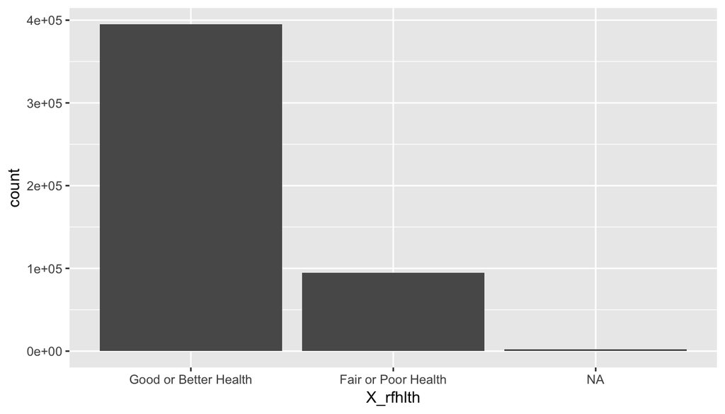

```r
ggplot(brfss2013, mapping = aes(x = X_rfhlth)) +
  geom_bar(stat = "count")
```

*This bar plot shows the frequency distribution of ‘Adults with good or better health’ variable*

Now, we create a subset of data consisting of only the coastal states and territories. All NA’s and no responses are excluded.

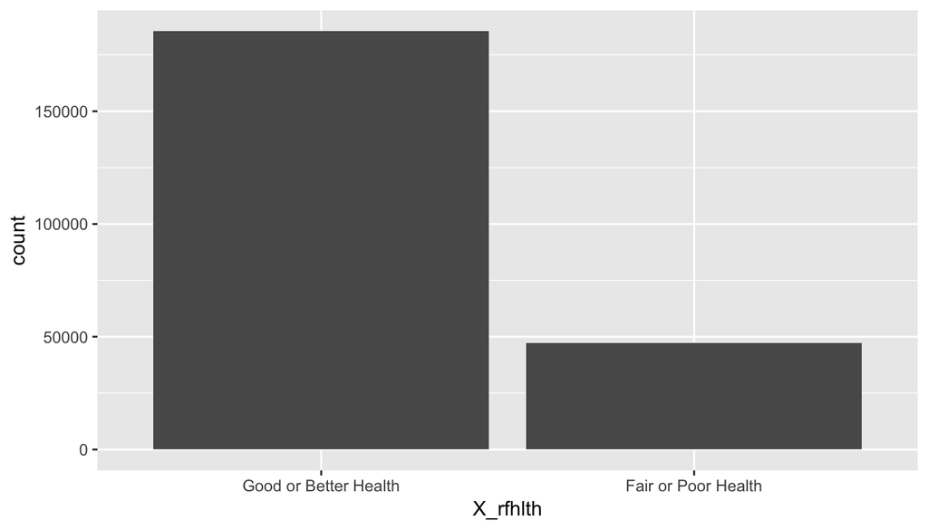

```r
coastal <- filter(brfss2013, coastal_state == TRUE, !is.na(X_rfhlth))
  coastal_total <- nrow(coastal)
  coastal_goodhealth <- nrow(filter(coastal, X_rfhlth == "Good or Better Health"))
  coastal_gh_proportion <- coastal_goodhealth/coastal_total

coastal %>%
  ggplot(aes(x = X_rfhlth)) +
  geom_bar(stat = "count")
```

*Bar plot of the frequency distribution for coastal states only*

Proportion of people with good or better health in coastal states and territories:

```r
show(coastal_gh_proportion)
```

```
## [1] 0.7970221
```

Similarly, we create a subset of landlocked states.

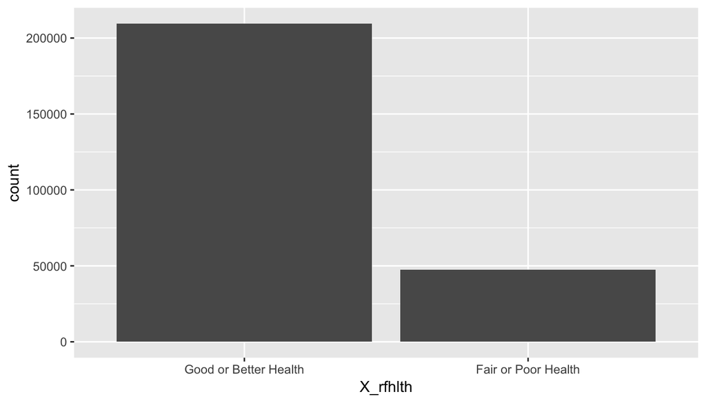

```r
landlocked <- filter(brfss2013, coastal_state == FALSE, !is.na(X_rfhlth))
  landlocked_total <- nrow(landlocked)
  landlocked_goodhealth <- nrow(filter(landlocked, X_rfhlth == "Good or Better Health"))
  landlocked_gh_proportion <- landlocked_goodhealth/landlocked_total

landlocked %>%
  ggplot(aes(x = X_rfhlth)) +
  geom_bar(stat = "count")
```

*Bar plot of the frequency distribution for landlocked states only*

Proportion of people with good or better health in landlocked states:

```r
show(landlocked_gh_proportion)
```

```
## [1] 0.8154652
```

We can see that the proportion of people with good or better health in landlocked states is higher: 81.6% in landlocked states and 79.7% in coastal ones. This means that the average person in a coastal state has no better health than one in a landlocked state.

However, health care in the US territories like Puerto Rico and Guam may differ from one in main states, so we can exclude them from the analysis to see if the proportion changes.

```r
coastal_no_territories <- filter(coastal, X_state != "Guam", X_state != "Puerto Rico")
  cnt_total <- nrow(coastal_no_territories)
  cnt_goodhealth <- nrow(filter(coastal_no_territories, X_rfhlth == "Good or Better Health"))
  cnt_gh_proportion <- cnt_goodhealth/cnt_total

## Proportion of people with good or better health in states without Guam and Puerto Rico
  show(cnt_gh_proportion)
```

```
## [1] 0.801955
```

In fact, the proportion of people with good or better health in coastal states excluding Guam and Puerto Rico slightly increased and got even closer to one in landlocked states (80.2% and 81.6% respectively).

*Step 4*  
We can also check if an average person in a coastal state has a higher chance of reporting ‘Excellent’ health.

```r
coastal_excellenthlth <- nrow(filter(coastal, genhlth == "Excellent"))
coastal_eh_proportion <- coastal_excellenthlth/coastal_total

landlocked_excellenthlth <- nrow(filter(landlocked, genhlth == "Excellent"))
landlocked_eh_proportion <- landlocked_excellenthlth/landlocked_total

cnt_excellenthlth <- nrow(filter(coastal_no_territories, genhlth == "Excellent"))
cnt_eh_proportion <- cnt_excellenthlth/cnt_total
```

Proportions of people reporting Excellent health in coastal, landlocked, and coastal excluding territories states:

```
## [1] 0.1793445
```

```
## [1] 0.1701617
```

```
## [1] 0.1799177
```

**Research question 2:**

#### Do you drink more soda than your grandpa?

We would need to work with two variables here: **X_age_g** - Imputed Age In Six Groups, and **ssbsugar** - How Often Do You Drink Regular Soda Or Pop?

*Step 1*  
We need to check the variables for errors and NAs first.

```r
brfss2013 %>%
  group_by(X_age_g) %>%
  summarise(n())
```

```
## # A tibble: 7 x 2
##   X_age_g          `n()`
##   <fct>            <int>
## 1 Age 18 to 24     27203
## 2 Age 25 to 34     50164
## 3 Age 35 to 44     60416
## 4 Age 45 to 54     83769
## 5 Age 55 to 64    109464
## 6 Age 65 or older 160747
## 7 <NA>                12
```

```r
brfss2013 %>%
  group_by(ssbsugar) %>%
  summarise(n())
```

```
## # A tibble: 94 x 2
##    ssbsugar `n()`
##       <int> <int>
##  1        0 46115
##  2      101  8317
##  3      102  3647
##  4      103  1361
##  5      104   599
##  6      105   324
##  7      106   192
##  8      107    72
##  9      108    58
## 10      109     3
## # … with 84 more rows
```

For X_age_g, we deal with a categorical ordinal variable. It’s not a surprise that the most populous category presented is people aged 65 or older as it’s not limited by 10-years range as other groups. Note that the first category (18-24) is the least populous for the same reason - the range here only spans 7 years. There are just a few cases with NAs, but we’d need to exclude them anyway.

The second variable, ssbsugar, is a little bit confusing as it shows the frequencies of consuming soda drinks in different formats. Respondents could answer times per day, week, or month. We should decode the values based on the following encoding rules: the first number denotes numbers of times per day (1), week (2), or month (3). The remaining numbers represent the counts of times. Let’s transfer all of these values to a unified format - soda drinks per day - and save it as a new variable.

*Step 2*  
Calculate new variable - sodas_per_day.

```r
brfss2013 <- brfss2013 %>%
  mutate(sodas_per_day =
    ifelse (is.na(ssbsugar), NA, ifelse (ssbsugar == 0, 0, ifelse (0<(ssbsugar - 300), (ssbsugar - 300)/30, ifelse (0<(ssbsugar - 200), (ssbsugar - 200)/7, ssbsugar-100)))))

# The summary statistics for the new variable:
brfss2013 %>%
  filter(!is.na(sodas_per_day)) %>%
  summarise(soda_median = median(sodas_per_day), soda_mean = mean(sodas_per_day), sodas_min = min(sodas_per_day), sodas_max = max(sodas_per_day), IQR = IQR(sodas_per_day), count = n())
```

```
##   soda_median soda_mean sodas_min sodas_max       IQR  count
## 1  0.03333333 0.3632659         0        40 0.2857143 103195
```

*Step 3*  
It’s time to find out the distributions of soda drinkers within the age groups.

```r
brfss2013 %>%
  filter(!is.na(sodas_per_day),  !is.na(X_age_g)) %>%
  group_by(X_age_g) %>%
  summarise(soda_median = round(median(sodas_per_day), 6), soda_mean = round(mean(sodas_per_day), 3), sodas_min = round(min(sodas_per_day), 3), soda_max = max(sodas_per_day), IQR = round(IQR(sodas_per_day), 3), soda_sd = round(sd(sodas_per_day), 3), count = n())
```

```
## # A tibble: 6 x 8
##   X_age_g      soda_median soda_mean sodas_min soda_max   IQR soda_sd count
##   <fct>              <dbl>     <dbl>     <dbl>    <dbl> <dbl>   <dbl> <int>
## 1 Age 18 to 24      0.286      0.688         0       13 0.967   1.21   4849
## 2 Age 25 to 34      0.143      0.636         0       21 1       1.23   9759
## 3 Age 35 to 44      0.1        0.498         0       30 0.5     1.07  13191
## 4 Age 45 to 54      0.0667     0.41          0       30 0.333   1.01  18333
## 5 Age 55 to 64      0          0.288         0       15 0.167   0.712 24093
## 6 Age 65 or o…      0          0.21          0       40 0.143   0.63  32967
```

We can see unusual similarities in the values of the median for some groups (like 0 for two oldest groups). In fact, it’s nothing weird. This means that at least 50% of older people don’t consume soda at all. Good to know!

We can now represent the distributions within the age groups visually. The boxplot fits this need perfectly.

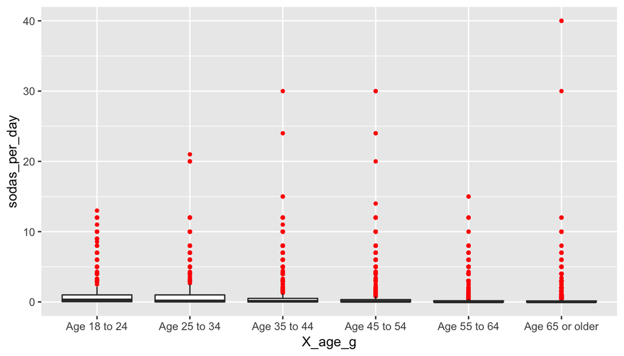

```r
brfss2013 %>%
  filter(!is.na(sodas_per_day), !is.na(X_age_g)) %>%
  ggplot(aes(x = X_age_g, y = sodas_per_day)) +
  geom_boxplot(outlier.color = "red", outlier.size = 1, notch = FALSE, varwidth = FALSE, na.rm = TRUE)
```

```r
# brfss2013 %>%
#   filter(!is.na(sodas_per_day), !is.na(X_age_g), sodas_per_day != 0) %>%
#   ggplot(aes(x = X_age_g, y = sodas_per_day)) +
#   geom_violin()
```

*This boxplot shows the distribution of soda drinkers within the age groups*

There is a number of outliers that affect the scale of the plot and make it hard to read. We can cut the most extreme outliers (over 5 soda drinks per day) without skewing the distribution too much.

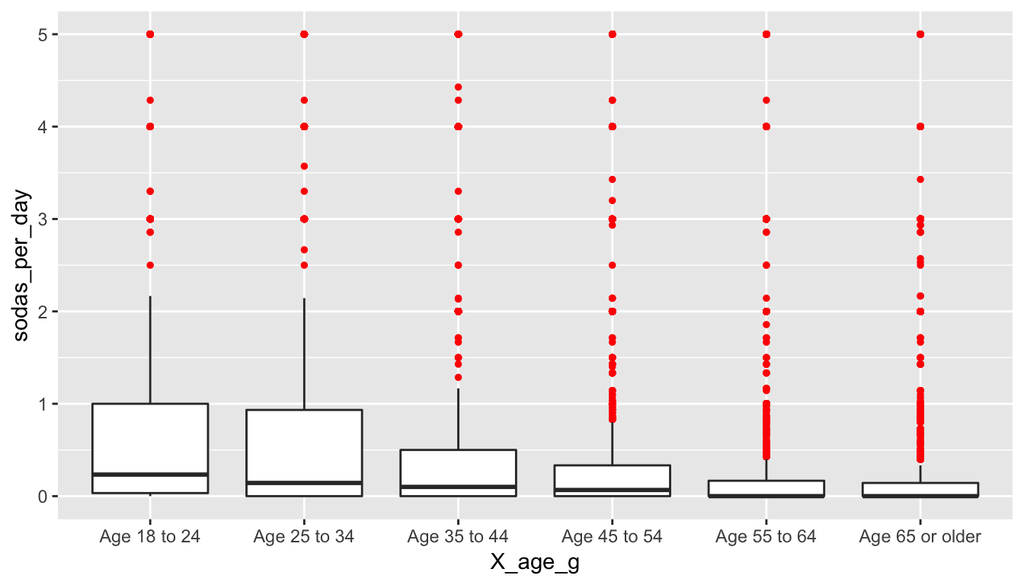

```r
brfss2013 %>%
  filter(!is.na(sodas_per_day), !is.na(X_age_g),  sodas_per_day <= 5) %>%
  ggplot(aes(x = X_age_g, y = sodas_per_day)) +
  geom_boxplot(outlier.color = "red", outlier.size = 1, notch = FALSE, varwidth = FALSE, na.rm = TRUE)
```

*This boxplot shows the distribution within the age groups with extreme outliers cut-off*

Data shows that ‘18-24’ group has the highest median number of drinks per day (0.29 per day, or almost 9 soda drinks per month), and both ‘55-64’ and ‘65+’ has the lowest (zero soda drinks per day). The rest of the age groups show the values somewhere in between. The trend line is certainly downward.

**Conclusion**  
It’s clear now that soda consumption has a strong negative correlation with age. People consume less soda as they become older. The answer to question 2 depends on your age, but there’s a good chance that **if you drink any soda and you’re younger than 55, you drink more soda than your grandpa**.

**Research question 3:**

#### Does a smoker have a higher chance to live alone?

*Step 1*  
We need to define variables of interest first. The variable **‘numadult’** represents the number of adults in the household. This is a discrete variable with numerical values. Another variable of interest is **‘smokday2’** which shows the frequency of days currently smoking.

Numadult takes the values between 1 and 45 in this data frame with lots of NAs that we would need to exclude from the analysis. We are interested in cases with 1 adult in the household.

Also, we should only consider the households with one adult and no children in them - the categorical variable **‘X_chldcnt’**, Computed Number Of Children In Household, is handy here.

```r
brfss2013 %>%
  filter(X_chldcnt == "No children in household", !is.na(numadult)) %>%
  group_by(numadult) %>%
  summarise(n())
```

```
## # A tibble: 14 x 2
##    numadult  `n()`
##    <fct>     <int>
##  1 1        116601
##  2 2        135187
##  3 3         20197
##  4 4          6094
##  5 5          1190
##  6 6           252
##  7 7            36
##  8 8            19
##  9 9             5
## 10 10            4
## 11 12            1
## 12 16            2
## 13 17            1
## 14 45            1
```

This var takes values from Every Day to Some days to Not at all. For this test, we would consider a person a smoker if s/he smokes every day or some days. There’s a calculated value in this data frame that counts all smokers and non-smokers for us, **X_rfsmok3**. We’ll be using this variable in future analysis.

```r
brfss2013 %>%
  group_by(smokday2) %>%
  summarise(n())
```

```
## # A tibble: 4 x 2
##   smokday2    `n()`
##   <fct>       <int>
## 1 Every day   55163
## 2 Some days   21494
## 3 Not at all 138135
## 4 <NA>       276983
```

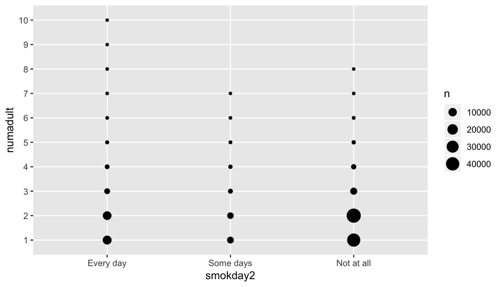

```r
brfss2013 %>%
  filter(!is.na(smokday2), !is.na(numadult), X_chldcnt == "No children in household") %>%
  ggplot(aes(x = smokday2, y = numadult)) +
  geom_count()
```

*The count plot above shows the size of a household and smoker status with the number of cases*

*Step 2*  
Here’s the summary showing the relationship between the smokers (X_rfsmok3) and the number of adults in a household (numadult).

```r
brfss2013 %>%
  filter(!is.na(X_rfsmok3), !is.na(numadult), X_chldcnt == "No children in household") %>%
  group_by(X_rfsmok3, numadult) %>%
  summarise(n())
```

```
## # A tibble: 24 x 3
## # Groups:   X_rfsmok3 [2]
##    X_rfsmok3 numadult  `n()`
##    <fct>     <fct>     <int>
##  1 No        1         96320
##  2 No        2        116528
##  3 No        3         16486
##  4 No        4          4988
##  5 No        5           964
##  6 No        6           207
##  7 No        7            27
##  8 No        8            14
##  9 No        9             3
## 10 No        10            3
## # … with 14 more rows
```

We’re only interested in households with 1 adult with no children. Those households with more than one adult should be combined into one group. We then need to create additional variable ‘home_alone’ consisting of 2 values: TRUE and FALSE.

```r
brfss2013 <- brfss2013 %>%
  mutate(home_alone = ifelse(numadult == 1, ifelse(X_chldcnt == "No children in household", TRUE, FALSE), FALSE))
```

The following code calculates the values needed for the contingency table.

```r
# Create a contingency table with two categorical vars:
smokers_tab1 <- with(brfss2013,
  table(X_rfsmok3, home_alone))

# Show table
smokers_tab1
```

```
##          home_alone
## X_rfsmok3  FALSE   TRUE
##       No  204049  96320
##       Yes  32157  16811
```

```r
# Show percents
prop.table(smokers_tab1)*100
```

```
##          home_alone
## X_rfsmok3     FALSE      TRUE
##       No  58.410360 27.572230
##       Yes  9.205151  4.812259
```

```r
# Total for smokers/non-smokers
rowSums(smokers_tab1)
```

```
##     No    Yes
## 300369  48968
```

```r
# Total for alone/not-alone
colSums(smokers_tab1)
```

```
##  FALSE   TRUE
## 236206 113131
```

*Step 3*  
We can now find if a proportion of **smokers living alone** exceeds a proportion of **non-smokers living alone**.

```r
prop.table(smokers_tab1, margin = 1)*100
```

```
##          home_alone
## X_rfsmok3    FALSE     TRUE
##       No  67.93278 32.06722
##       Yes 65.66942 34.33058
```

Indeed, we can see that 34.33% of smokers live alone against 32.07% of non-smokers living alone.

Taking the other way around, we can check if a random person being **the only member of his or her household** has a higher chance of **being a smoker**, than has a person living with somebody. Since we already have all of the values from a contingency table, it’s quite easy to calculate:

```r
prop.table(smokers_tab1, margin = 2)*100
```

```
##          home_alone
## X_rfsmok3    FALSE     TRUE
##       No  86.38604 85.14024
##       Yes 13.61396 14.85976
```

Again, we can see a higher chance of living alone and being a smoker, than living with somebody and being a smoker: 14.86% and 13.61% respectively.

**Conclusion**  
We found out that an average smoker has a 2.26% higher chance of living alone, than a non-smoker. Also, an average person living alone has 1.25% higher chance of being a smoker than one living with somebody. This makes sense but doesn’t mean that these two factors are really connected. There might be a confounding variable affecting both of them instead. Anyway, **the answer to question 3 is YES**.